# Asymptotic foundations

## 'math+econ+code' masterclass series: econometrics

#### CLT, CMT, Slutsky, and a first confidence interval

© 2018–2026 by Alfred Galichon. Past and present support from NSF grant DMS-1716489, ERC grant CoG-866274 are acknowledged, as well as inputs from contributors listed [here](http://www.math-econ-code.org/team).

**If you reuse material from this masterclass, please cite as:**  
Alfred Galichon, 'math+econ+code' masterclass series. https://www.math-econ-code.org/

### Learning objectives

- Use the Central Limit Theorem (CLT) to derive the asymptotic distribution of sample averages, and read the Berry–Esseen theorem as a statement about its rate of convergence.
- Combine the CLT with the Continuous Mapping Theorem (CMT) and Slutsky's theorem to deduce the asymptotic distribution of derived statistics such as the studentized sample mean.
- Assemble these tools into an *asymptotic* confidence interval for a population mean, and benchmark it against the exact-Gaussian ($t_{I-1}$) interval on real data.

This lecture continues directly from **Lecture 1** (conditional expectations, modes of convergence, and the Law of Large Numbers).

### References

**[H]** Hansen, B. E. (2022). *Econometrics*. Princeton University Press. Chapters 5–6. Online at https://users.ssc.wisc.edu/~bhansen/econometrics/.

**[vdV]** van der Vaart, A. W. (1998). *Asymptotic Statistics*. Cambridge University Press.

**[CB]** Casella, G., and Berger, R. L. (2002). *Statistical Inference*, 2nd edition. Duxbury.

**[M]** Mroz, T. A. (1987). 'The Sensitivity of an Empirical Model of Married Women's Hours of Work to Economic and Statistical Assumptions'. *Econometrica*, 55(4), 765–799.

# Motivation: completing the asymptotic toolkit

Lecture 1 introduced the conditional expectation function, the modes of convergence, and the Law of Large Numbers: the statement that a sample average converges to its population counterpart. The LLN tells us *where* an estimator settles; it says nothing about the *shape* of its sampling distribution or how to build a confidence interval.

We shall now introduce the remaining tools. The Central Limit Theorem gives the Gaussian shape of a centered, rescaled sample average; the Continuous Mapping Theorem and Slutsky's theorem propagate that shape through the smooth transformations that turn a raw average into a usable statistic. We keep the same simulation-first approach, and close by assembling all four tools into an asymptotic confidence interval on the Mroz (1987) log-wage data introduced in Lecture 1.

## Loading our libraries

We start with the standard scientific Python stack.

```python
import numpy as np
import pandas as pd
import matplotlib.pyplot as plt
from scipy import stats

rng = np.random.default_rng(777)
plt.rcParams['figure.figsize'] = (8, 4.5)
```

## Loading our data

We use Mroz's (1987) cross-section of $I=753$ married women, of whom $428$ report a positive hourly wage. The dataset is hosted as a CSV on Vincent Arel-Bundock's `Rdatasets` repository, which mirrors the standard R packages used in econometrics teaching. (If the URL is unreachable, an offline alternative is `pip install wooldridge` followed by `wooldridge.data('mroz')`, modulo a small column-name change: in that variant the labor-force-participation indicator is `inlf` rather than `lfp`.)

```python
url = 'https://vincentarelbundock.github.io/Rdatasets/csv/sampleSelection/Mroz87.csv'
try:
    mroz = pd.read_csv(url)                       # Rdatasets Mroz87 (needs a network)
except Exception:
    # Offline fallback: the identical Mroz (1987) data ships with the `wooldridge` package.
    import wooldridge
    mroz = (wooldridge.data('mroz')
            .rename(columns={'inlf': 'lfp', 'kidslt6': 'kids5', 'kidsge6': 'kids618'})
            .copy())
print(f'Number of observations: {len(mroz)}')
print(f'Working women (lfp=1):  {(mroz["lfp"]==1).sum()}')
mroz.head(3)
```

```
Number of observations: 753
Working women (lfp=1):  428
```

|  | lfp | hours | kids5 | kids618 | age | educ | wage | repwage | hushrs | husage | ... | faminc | mtr | motheduc | fatheduc | unem | city | exper | nwifeinc | lwage | expersq |
| --- | --- | --- | --- | --- | --- | --- | --- | --- | --- | --- | --- | --- | --- | --- | --- | --- | --- | --- | --- | --- | --- |
| 0 | 1 | 1610 | 1 | 0 | 32 | 12 | 3.3540 | 2.65 | 2708 | 34 | ... | 16310.0 | 0.7215 | 12 | 7 | 5.0 | 0 | 14 | 10.910060 | 1.210154 | 196 |
| 1 | 1 | 1656 | 0 | 2 | 30 | 12 | 1.3889 | 2.65 | 2310 | 30 | ... | 21800.0 | 0.6615 | 7 | 7 | 11.0 | 1 | 5 | 19.499981 | 0.328512 | 25 |
| 2 | 1 | 1980 | 1 | 3 | 35 | 12 | 4.5455 | 4.04 | 3072 | 40 | ... | 21040.0 | 0.6915 | 12 | 7 | 5.0 | 0 | 15 | 12.039910 | 1.514138 | 225 |

3 rows × 22 columns

For the rest of the lecture we restrict attention to working women, for whom the hourly wage `wage` is positive and observed. We also create the log-wage variable `lwage`.

```python
mroz_w = mroz.loc[mroz['lfp'] == 1].copy()
mroz_w['lwage'] = np.log(mroz_w['wage'])
print(f'I = {len(mroz_w)}')
print(mroz_w[['wage', 'lwage', 'educ', 'exper']].describe().round(2))
```

```
I = 428
         wage   lwage    educ   exper
count  428.00  428.00  428.00  428.00
mean     4.18    1.19   12.66   13.04
std      3.31    0.72    2.29    8.06
min      0.13   -2.05    5.00    0.00
25%      2.26    0.82   12.00    7.00
50%      3.48    1.25   12.00   12.00
75%      4.97    1.60   14.00   18.00
max     25.00    3.22   17.00   38.00
```

# 1. The Central Limit Theorem

## 1.1 Statement

**Theorem (Lindeberg–Lévy CLT).** If $(X_i)_{i\geq 1}$ are i.i.d. with $\mathbb{E}[X_1]=\mu$ and $\operatorname{Var}(X_1)=\sigma^2\in(0,\infty)$, then $$ \sqrt{I}\,(\bar X_I - \mu)\xrightarrow{d} \mathcal{N}(0,\sigma^2). $$

The CLT explains the universality of the normal distribution in econometrics: as long as the underlying random variables have a finite second moment, the sampling distribution of any sample mean, appropriately re-centered and re-scaled, looks Gaussian.

## 1.2 Simulation across parent distributions

For four very different parent distributions, we draw $M=20\,000$ Monte Carlo samples of size $I$, compute the studentized sample mean $$ Z_I^{(m)} := \frac{\sqrt{I}\,\bigl(\bar X_I^{(m)}-\mu\bigr)}{\sigma}, $$ and overlay its histogram against the standard normal density.

```python
def clt_simulation(sampler, mu, sigma, I=200, R=20_000):
    X_r_i = sampler(size=(R, I))     # R Monte Carlo samples (r in [R]) of I individuals (i in [I])
    mean_r = X_r_i.mean(axis=1)
    Z_r = np.sqrt(I) * (mean_r - mu) / sigma
    return Z_r

specs_clt = {
    'Uniform(0,1)':       (lambda size: rng.random(size), 0.5,  np.sqrt(1/12)),
    'Exponential(1)':     (lambda size: rng.exponential(1.0, size), 1.0, 1.0),
    'Bernoulli(0.1)':     (lambda size: (rng.random(size) < 0.1).astype(float), 0.1, np.sqrt(0.1*0.9)),
    'Lognormal(0,1)':     (lambda size: rng.lognormal(0.0, 1.0, size), np.exp(0.5), np.sqrt((np.exp(1)-1)*np.exp(1))),
}

I = 200
R = 20_000
S = len(specs_clt)
Z_s_r = np.empty((S, R))
for s, (_, (sampler, mu, sigma)) in enumerate(specs_clt.items()):
    Z_s_r[s] = clt_simulation(sampler, mu, sigma, I=I, R=R)

z_g = np.linspace(-4, 4, 400)
```

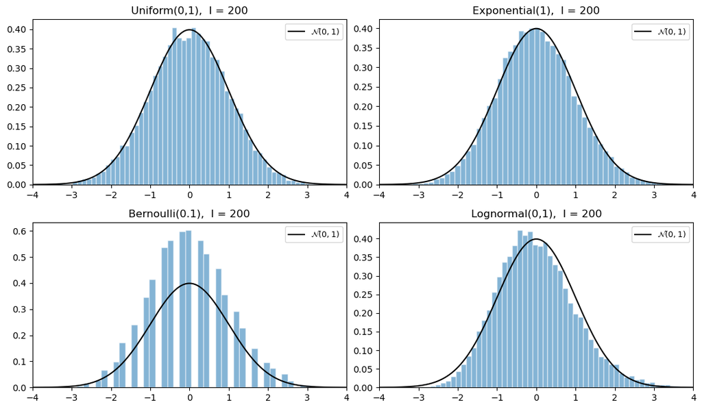

```python
fig, axes = plt.subplots(2, 2, figsize=(11, 6.5))
for s, (ax, name) in enumerate(zip(axes.flat, specs_clt)):
    ax.hist(Z_s_r[s], bins=60, density=True, alpha=0.55, edgecolor='white')
    ax.plot(z_g, stats.norm.pdf(z_g), 'k-', lw=1.5, label=r'$\mathcal{N}(0,1)$')
    ax.set_xlim(-4, 4)
    ax.set_title(f'{name},  I = {I}')
    ax.legend(loc='upper right', fontsize=9)
plt.tight_layout()
plt.show()
```

The Bernoulli(0.1) panel illustrates that the CLT requires $I$ to be large *relative to the non-normality of the parent distribution*. The quantity that governs the rate is not skewness but the standardized third **absolute** moment $\rho/\sigma^3$ with $\rho = \mathbb{E}\lvert X-\mu\rvert^3$, which appears in the Berry–Esseen bound below. The two are different: a symmetric but heavy-tailed parent has zero skewness and can still have a large $\rho/\sigma^3$, and so a slow approach to normality. In this particular panel the parent does happen to be skewed: with success probability 0.1, the sampling distribution of the mean is still visibly discrete and right-skewed at $I=200$. The *Berry–Esseen theorem*, stated next, makes this precise.

## 1.3 Rate of convergence: the Berry–Esseen theorem

The CLT tells us that $Z_I=\sqrt{I}(\bar X_I-\mu)/\sigma \xrightarrow{d}\mathcal{N}(0,1)$, but on its own it says nothing about *how fast*. The Berry–Esseen theorem supplies a uniform, non-asymptotic rate.

**Theorem (Berry–Esseen).** Let $(X_i)_{i\ge 1}$ be i.i.d. with mean $\mu$, variance $\sigma^2\in(0,\infty)$, and finite third absolute moment $\rho:=\mathbb{E}\lvert X_1-\mu\rvert^3<\infty$. Then, with $\Phi$ the standard-normal CDF, $$ \sup_{x\in\mathbb{R}}\bigl\lvert\,\mathbb{P}(Z_I\le x)-\Phi(x)\,\bigr\rvert \;\le\; \frac{C\,\rho}{\sigma^3\,\sqrt{I}}, $$ where $C$ is an absolute constant: the same for every distribution (the best known value is $C<0.4748$).

Two readings of the bound:

- **Rate.** The worst-case (Kolmogorov) distance between the exact sampling distribution and its Gaussian limit vanishes like $I^{-1/2}$; halving the error takes roughly four times as much data.
- **Constant.** It is proportional to the *standardized third absolute moment* $\rho/\sigma^3$. This is a scale-free measure of how heavy the third-order absolute deviations are, **not** a measure of asymmetry, and not skewness, as the opening of this section noted. It cannot be small merely because a distribution is symmetric: the standard normal itself has $\rho/\sigma^3 = 2\sqrt{2/\pi}\approx 1.60$, and a symmetric heavy-tailed parent has a larger one still. What makes Bernoulli(0.1) converge slowly is that its standardized absolute third moment is large, which here happens to come with marked asymmetry, but the two need not travel together.

```python
# Berry-Esseen bounds the Kolmogorov distance  sup_x |P(Z_I <= x) - Phi(x)|  by
# C * rho / (sigma**3 * sqrt(I)),  with rho = E|X - mu|**3 the third absolute moment.
# We estimate that sup by the Kolmogorov-Smirnov (KS) distance below, then check that
# it decays at the predicted I^(-1/2) rate (a straight line of slope -1/2 on log-log axes).

def ks_distance(Z_r):
    """Two-sided Kolmogorov distance  sup_x |F_emp(x) - Phi(x)|.

    The empirical CDF is a step function, so at each order statistic z_(r) the gap has to be
    measured on BOTH sides of the jump: r/R - Phi(z_(r)) just after it, and Phi(z_(r)) -
    (r-1)/R just before it. Taking only the first understates the supremum.
    """
    Z_sorted_r = np.sort(Z_r)
    R = len(Z_sorted_r)
    F_th_r = stats.norm.cdf(Z_sorted_r)
    d_plus  = np.max(np.arange(1, R + 1) / R - F_th_r)      # above the step
    d_minus = np.max(F_th_r - np.arange(0, R) / R)          # below the step
    return max(d_plus, d_minus)

# Cross-check the implementation against scipy's two-sided one-sample KS statistic.
_z_check = rng.standard_normal(4_000)
assert abs(ks_distance(_z_check)
           - stats.kstest(_z_check, 'norm').statistic) < 1e-12, 'KS distance mismatch'
print('ks_distance agrees with scipy.stats.kstest to machine precision')

I_s = np.array([10, 30, 100, 300, 1000, 3000, 10_000])   # grid of sample sizes, s in [S]
R = 5_000
sampler = lambda size: rng.exponential(1.0, size)
mu, sigma = 1.0, 1.0

ks_s = np.empty(len(I_s))
for s, I in enumerate(I_s):
    Z_r = clt_simulation(sampler, mu, sigma, I=I, R=R)
    ks_s[s] = ks_distance(Z_r)
```

```
ks_distance agrees with scipy.stats.kstest to machine precision
```

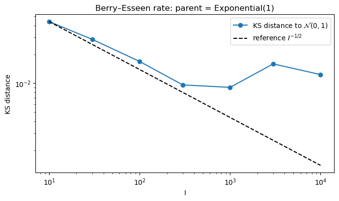

```python
fig, ax = plt.subplots(figsize=(7, 4.2))
ax.loglog(I_s, ks_s, 'o-', label=r'KS distance to $\mathcal{N}(0,1)$')
ax.loglog(I_s, ks_s[0] * np.sqrt(I_s[0] / I_s), 'k--', label=r'reference $I^{-1/2}$')
ax.set_xlabel('I')
ax.set_ylabel('KS distance')
ax.set_title('Berry–Esseen rate: parent = Exponential(1)')
ax.legend()
plt.tight_layout()
plt.show()
```

# 2. The Continuous Mapping Theorem

**Theorem (CMT).** Let $g:\mathbb{R}^k\to\mathbb{R}^\ell$ be a function continuous on a set $C$ with $\mathbb{P}(X\in C)=1$. Then:

- if $X_n\xrightarrow{a.s.}X$, then $g(X_n)\xrightarrow{a.s.}g(X)$;
- if $X_n\xrightarrow{p}X$, then $g(X_n)\xrightarrow{p}g(X)$;
- if $X_n\xrightarrow{d}X$, then $g(X_n)\xrightarrow{d}g(X)$.

The CMT lets us propagate convergence statements through smooth functions without re-doing the work. Combined with the LLN, it yields many consistency results.

## 2.1 Application: consistency of the sample variance

The sample variance $S_I^2=\frac{1}{I}\sum_{i\in[I]} (X_i-\bar X_I)^2$ admits the algebraic identity $$ S_I^2 = \frac{1}{I}\sum_{i\in[I]} X_i^2 \;-\; \bar X_I^{\,2}. $$ By the LLN applied to $X_i$ and to $X_i^2$, the two sample averages converge in probability to $\mathbb{E}[X_1]$ and $\mathbb{E}[X_1^2]$ respectively. By the CMT applied to the continuous map $(a,b)\mapsto b - a^2$, $$ S_I^2 \xrightarrow{p} \mathbb{E}[X_1^2] - \mathbb{E}[X_1]^2 = \sigma^2. $$

(We use the $\tfrac{1}{I}$ divisor here for the clean CMT argument; the studentized mean and confidence interval in §3–§4 use the unbiased $\tfrac{1}{I-1}$ version, for which the exact finite-sample distribution is $t_{I-1}$ under normality. The two are asymptotically equivalent.) We verify this on a Lognormal sample, whose true variance equals $(e-1)e\approx 4.6708$.

```python
I_s = np.unique(np.round(np.logspace(1, 4, 30)).astype(int))   # grid of sample sizes, s in [S]
R = 5
sigma2_true = (np.exp(1) - 1) * np.exp(1)
s2_r_s = np.empty((R, len(I_s)))
for r in range(R):
    x_i = rng.lognormal(0.0, 1.0, size=I_s.max())
    s2_r_s[r] = np.array([x_i[:I].var(ddof=0) for I in I_s])
```

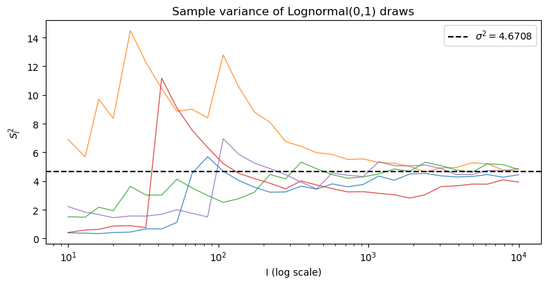

```python
fig, ax = plt.subplots(figsize=(8, 4.2))
for r in range(R):
    ax.plot(I_s, s2_r_s[r], lw=0.9, alpha=0.85)
ax.axhline(sigma2_true, color='k', ls='--', label=fr'$\sigma^2 = {sigma2_true:.4f}$')
ax.set_xscale('log')
ax.set_xlabel('I (log scale)')
ax.set_ylabel(r'$S_I^2$')
ax.set_title('Sample variance of Lognormal(0,1) draws')
ax.legend()
plt.tight_layout()
plt.show()
```

# 3. Slutsky's theorem

**Theorem (Slutsky).** If $X_n\xrightarrow{d}X$ and $Y_n\xrightarrow{p}c$ for a constant $c$, then:

- $X_n + Y_n \xrightarrow{d} X + c$,
- $X_n\, Y_n \xrightarrow{d} c\, X$,
- $X_n / Y_n \xrightarrow{d} X / c$ (provided $c\neq 0$).

Slutsky's theorem is the standard tool that converts asymptotic-normality statements into usable inference. The pattern is the following: a properly studentized statistic typically splits into a piece that satisfies a CLT (so converges in distribution to a Gaussian) and a piece that converges in probability to a constant. Slutsky tells us the joint object inherits the CLT.

## 3.1 The studentized sample mean

The classical application is the $t$-statistic $$ T_I = \frac{\sqrt{I}\,(\bar X_I - \mu)}{S_I}. $$ Decompose $T_I = (\sqrt{I}\,(\bar X_I-\mu)/\sigma)\cdot(\sigma/S_I)$. The first factor satisfies the CLT (converges in distribution to $\mathcal{N}(0,1)$); the second factor converges in probability to $1$ by the LLN combined with the CMT (applied to $u\mapsto\sigma/\sqrt{u}$, which is continuous at $u=\sigma^2>0$). By Slutsky's theorem, $$ T_I \xrightarrow{d} \mathcal{N}(0,1). $$

## 3.2 Simulation

```python
def t_simulation(sampler, mu, I=20, R=20_000):
    X_r_i = sampler(size=(R, I))
    mean_r = X_r_i.mean(axis=1)
    sd_r = X_r_i.std(axis=1, ddof=1)
    T_r = np.sqrt(I) * (mean_r - mu) / sd_r
    return T_r

I = 20
R = 20_000
sampler = lambda size: rng.exponential(1.0, size)
T_r = t_simulation(sampler, mu=1.0, I=I, R=R)

# Empirical CDF vs N(0,1) and t_{I-1}
T_sorted_r = np.sort(T_r)
F_emp_r = np.arange(1, R+1) / R
z_g = np.linspace(-5, 5, 400)

# Q-Q plot vs N(0,1)
u_q = np.linspace(0.005, 0.995, 200)      # quantile levels, q in [Q]
qemp_q = np.quantile(T_r, u_q)
qth_q = stats.norm.ppf(u_q)
```

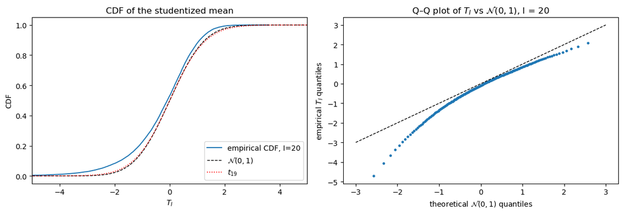

```python
fig, axes = plt.subplots(1, 2, figsize=(12, 4.2))

axes[0].plot(T_sorted_r, F_emp_r, lw=1.4, label=f'empirical CDF, I={I}')
axes[0].plot(z_g, stats.norm.cdf(z_g), 'k--', lw=1.0, label=r'$\mathcal{N}(0,1)$')
axes[0].plot(z_g, stats.t.cdf(z_g, df=I-1), 'r:', lw=1.2, label=fr'$t_{{{I-1}}}$')
axes[0].set_xlim(-5, 5)
axes[0].set_xlabel(r'$T_I$')
axes[0].set_ylabel('CDF')
axes[0].legend(loc='lower right')
axes[0].set_title('CDF of the studentized mean')

axes[1].plot(qth_q, qemp_q, 'o', ms=2.5)
axes[1].plot([-3, 3], [-3, 3], 'k--', lw=1.0)
axes[1].set_xlabel(r'theoretical $\mathcal{N}(0,1)$ quantiles')
axes[1].set_ylabel(r'empirical $T_I$ quantiles')
axes[1].set_title(fr'Q–Q plot of $T_I$ vs $\mathcal{{N}}(0,1)$, I = {I}')
plt.tight_layout()
plt.show()
```

# 4. Synthesis: an asymptotic confidence interval for the mean log-wage

We close the lecture by combining the four tools, LLN, CLT, CMT, Slutsky, to produce an *asymptotic* $1-\alpha$ confidence interval for $\mu = \mathbb{E}[\log\text{wage}]$ in the Mroz population. The construction reads: $$ \sqrt{I}\,(\bar X_I - \mu) \xrightarrow{d} \mathcal{N}(0,\sigma^2) \qquad\text{(CLT)}, $$ $$ S_I \xrightarrow{p} \sigma \qquad\text{(LLN + CMT)}, $$ $$ \frac{\sqrt{I}\,(\bar X_I-\mu)}{S_I}\xrightarrow{d}\mathcal{N}(0,1) \qquad\text{(Slutsky)}. $$ Inverting the last statement, $$ \mathrm{CI}_{1-\alpha} = \Bigl[\bar X_I - z_{1-\alpha/2}\,S_I/\sqrt{I},\;\;\bar X_I + z_{1-\alpha/2}\,S_I/\sqrt{I}\Bigr] $$ covers $\mu$ with probability tending to $1-\alpha$ as $I\to\infty$. We compute it on the Mroz working-women sample and benchmark it against the exact-Gaussian (i.e., $t_{I-1}$) interval one would obtain under a normality assumption.

```python
x_i = mroz_w['lwage'].values
I = len(x_i)
xbar = x_i.mean()
s = x_i.std(ddof=1)
se = s / np.sqrt(I)

alpha = 0.05
z = stats.norm.ppf(1 - alpha/2)
t_crit = stats.t.ppf(1 - alpha/2, df=I-1)

ci_asy = (xbar - z*se, xbar + z*se)
ci_exact = (xbar - t_crit*se, xbar + t_crit*se)

print(f'  I          = {I}')
print(f'  mean lwage = {xbar:.4f}')
print(f'  s.e.       = {se:.4f}')
print(f'  asymptotic 95% CI (CLT+Slutsky) = [{ci_asy[0]:.4f}, {ci_asy[1]:.4f}]')
print(f'  exact      95% CI (t_{I-1})       = [{ci_exact[0]:.4f}, {ci_exact[1]:.4f}]')
```

```
  I          = 428
  mean lwage = 1.1902
  s.e.       = 0.0350
  asymptotic 95% CI (CLT+Slutsky) = [1.1217, 1.2587]
  exact      95% CI (t_427)       = [1.1215, 1.2589]
```

The two intervals differ at the fourth decimal place, at $I=428$ the gap between $z_{0.975}\approx 1.960$ and $t_{427,0.975}\approx 1.966$ is numerically negligible. This is the practical implication of asymptotic theory: once $I$ is moderately large, the choice between the $t$ and normal critical values is irrelevant next to the width contributed by the estimated standard error itself, $S_I/\sqrt{I}$. That quantity is the **sampling** standard error of $\bar X_I$, the irreducible uncertainty from having $I$ observations rather than the whole population. It is not *Monte Carlo* error, which would be the separate numerical noise from running only $M$ simulation replications, and which we could shrink at will by raising $M$.

# Looking ahead

Lectures 1 and 2 together assembled the asymptotic toolkit, LLN, CLT, CMT, Slutsky, that the rest of the course deploys:

- In **Lecture 3** we set up the OLS estimator and develop its finite-sample theory, then apply Slutsky directly to obtain consistency.
- The following lecture derives the asymptotic normality of $\hat\beta_{\text{OLS}}$ and the heteroskedasticity-robust variance: the same CLT–CMT–Slutsky sandwich seen here, applied componentwise.
- Later (MLE, GMM, discrete choice) the same template recurs, with the sample average replaced by a sample score, a sample moment, or a sample log-likelihood.

Each subsequent estimator we encounter is, in this sense, a corollary of Lectures 1–2.